# Reproducible Research: Peer Assessment 2

Koen Deuze

## Synopsis

Storms and other severe weather events can cause both public health and economic problems for communities and municipalities. Many severe events can result in fatalities, injuries, and property damage, and preventing such outcomes to the extent possible is a key concern.

This project involves exploring the U.S. National Oceanic and Atmospheric Administration’s (NOAA) storm database. This database tracks characteristics of major storms and weather events in the United States, including when and where they occur, as well as estimates of any fatalities, injuries, and property damage.

In this report we try to answer two questions: 1) Across the United States, which types of events (as indicated in the EVTYPE variable) are most harmful with respect to population health? 2) Across the United States, which types of events have the greatest economic consequences?

## Load packages

```r
library(ggplot2) # enhanced grahics
library(ggthemes) # advanced themese
library(reshape2)
library(lattice)
library(plyr)
```

## Data reading

The data is read from https://d396qusza40orc.cloudfront.net/repdata%2Fdata%2FStormData.csv.bz2

```r
# download the zip file
download.file("https://d396qusza40orc.cloudfront.net/repdata%2Fdata%2FStormData.csv.bz2", destfile="./repdata-data-StormData.csv.bz2", method="curl")

# read the csv from the zipfile
stormdata <- read.csv('./repdata-data-StormData.csv.bz2', header=T)
```

## Data processing

We do some dataprocessing: - subsetting - event grouping

```r
# columnsubset the dataframe
stormdata <- stormdata[,c("EVTYPE","BGN_DATE","FATALITIES","INJURIES","PROPDMG","PROPDMGEXP","CROPDMG","CROPDMGEXP")]

# rowsubset the dataframe. The data before 1996 does not contain alle kind of events (only tornado, thunderstorm, wind and hail) so we only use the data starting in 1996
stormdata$YEAR <-  as.numeric(format(as.Date(stormdata$BGN_DATE, format = "%m/%d/%Y %H:%M:%S"), "%Y"))
stormdata <- subset(stormdata,stormdata$YEAR >= 1996)
stormdata <- stormdata[,c("EVTYPE","BGN_DATE","FATALITIES","INJURIES","PROPDMG","PROPDMGEXP","CROPDMG","CROPDMGEXP")]

# some datacleaning

# alle values to uppercase
stormdata$EVTYPE <- toupper(stormdata$EVTYPE)
# delete trailing and starting spaces
stormdata$EVTYPE <- trimws(stormdata$EVTYPE,"both")
# group some values
stormdata$EVTYPE <- revalue(stormdata$EVTYPE, c("COASTALFLOOD" = "COASTAL FLOODING"))
stormdata$EVTYPE <- revalue(stormdata$EVTYPE, c("NON-TSTM WIND" = "NON TSTM WIND"))
stormdata$EVTYPE <- revalue(stormdata$EVTYPE, c("TSTM WIND (G40)" = "TSTM WIND 40"))
stormdata$EVTYPE <- revalue(stormdata$EVTYPE, c("TSTM WIND (G45)" = "TSTM WIND 45"))
stormdata$EVTYPE <- revalue(stormdata$EVTYPE, c("NON-TSTM WIND"  = "NON TSTM WIND"))
stormdata$EVTYPE <- revalue(stormdata$EVTYPE, c("TSTM WIND  (G45)" = "TSTM WIND 45"))
stormdata$EVTYPE <- revalue(stormdata$EVTYPE, c("WND" = "WIND"))
stormdata$EVTYPE <- revalue(stormdata$EVTYPE, c("WINDS" = "WIND"))
stormdata$EVTYPE <- revalue(stormdata$EVTYPE, c("LAKESHORE FLOOD" = "FLOOD"))
stormdata$EVTYPE <- revalue(stormdata$EVTYPE, c("FLOOD/FLASH FLOOD" = "FLOOD"))
stormdata$EVTYPE <- revalue(stormdata$EVTYPE, c("COASTAL FLOODING" = "FLOOD"))
stormdata$EVTYPE <- revalue(stormdata$EVTYPE, c("EROSION/CSTL FLOOD" = "FLOOD"))
stormdata$EVTYPE <- revalue(stormdata$EVTYPE, c("URBAN/SML STREAM FLD" = "FLOOD"))
stormdata$EVTYPE <- revalue(stormdata$EVTYPE, c("ICE JAM FLOOD (MINOR" = "FLOOD"))
stormdata$EVTYPE <- revalue(stormdata$EVTYPE, c("URBAN FLOODING" = "FLOOD"))
stormdata$EVTYPE <- revalue(stormdata$EVTYPE, c("FLASH FLOOD/FLOOD" = "FLOOD"))
stormdata$EVTYPE <- revalue(stormdata$EVTYPE, c("FLASH FLOODING" = "FLOOD"))
stormdata$EVTYPE <- revalue(stormdata$EVTYPE, c("FLOOD/FLASH/FLOOD" = "FLOOD"))
stormdata$EVTYPE <- revalue(stormdata$EVTYPE, c("FLASH FLOOD" = "FLOOD"))
```

## Personal_health

We determine across the United States, which types of events (as indicated in the EVTYPE variable) are most harmful with respect to population health?

```r
# examine which events (based on EVTYPE in the dataset) are the most harmful to population health.
# we will make a difference between the number of injuries en the number of fatalities

# determine the number of injuries per event
injuries_per_event <- aggregate(stormdata$INJURIES, by=list(stormdata$EVTYPE), FUN=sum)
names(injuries_per_event) <- c("event","injuries")

# determine the number of fatalities per event
fatalities_per_event <- aggregate(stormdata$FATALITIES, by=list(stormdata$EVTYPE), FUN=sum)
names(fatalities_per_event) <- c("event","fatalities")

# merge the dataframes with injuries and fatalities
injuries_and_fatalities <- merge(x = fatalities_per_event, y = injuries_per_event, by = "event", all = TRUE)

# create a new column with the sum of the number of injuries and the number of fatalities
injuries_and_fatalities$total <- injuries_and_fatalities$injuries + injuries_and_fatalities$fatalities

# determine what is the top 10 of events with the most injuries and fatalities (combined)
top10_injuries_and_fatalities <- head(injuries_and_fatalities[order(injuries_and_fatalities$total,decreasing = T),],10)

# remove the total-column
top10_injuries_and_fatalities <- subset(top10_injuries_and_fatalities, select = c(event,injuries,fatalities) )

# reshape the dataframe to the columns: event, injury/fatality, count
melted_top10_injuries_and_fatalities <- melt(top10_injuries_and_fatalities, id.vars = 'event')
names(melted_top10_injuries_and_fatalities) <- c("Event", "fatality_injury", "Count")
top10_injuries_and_fatalities$fatality_injury = top10_injuries_and_fatalities$injuries + top10_injuries_and_fatalities$fatalities
```

## Economic_consequences

We determine across the United States, which types of events have the greatest economic consequences?

```r
# the column PRODMGEXP and CROPDMEXP contain alphabetical characters used to signify magnitude
# it contains “K” en "k" for thousands, “M” and "m" for millions, “B” and "b" for billions and "H" and "h" for hundreds.
temp_PROPDMG <- mapvalues(stormdata$PROPDMGEXP,
                          c("","-","?","+","0","1","2","3","4","5","6","7","8","B","h","H","K","m","M"),
                          c(1 ,1  ,1  ,1  , 1e0,1e1,1e2,1e3,1e4,1e5,1e6,1e7,1e8,1e9,1e2,1e2,1e3,1e6,1e6))
temp_CROPDMG <- mapvalues(stormdata$CROPDMGEXP,
                          c("","?","0","2","B","k","K","m","M"),
                          c(1 ,1  ,0  ,1e2,1e9,1e3,1e3,1e6,1e6))
stormdata$CALC_PROPDMG <- as.numeric(temp_PROPDMG) * stormdata$PROPDMG
stormdata$CALC_CROPDMG <- as.numeric(temp_CROPDMG) * stormdata$CROPDMG
stormdata$TOTAL_DMG <- stormdata$CALC_CROPDMG + stormdata$CALC_PROPDMG

# determine the damage per event
crop_damage_per_event <- aggregate(stormdata$CALC_CROPDMG, by=list(stormdata$EVTYPE), FUN=sum)
names(crop_damage_per_event) <- c("event","crop_damage")

prop_damage_per_event <- aggregate(stormdata$CALC_PROPDMG, by=list(stormdata$EVTYPE), FUN=sum)
names(prop_damage_per_event) <- c("event","prop_damage")

# merge the dataframes with cropdamage and propdamage
damage_per_event <- merge(x = crop_damage_per_event, y = prop_damage_per_event, by = "event", all = TRUE)

# create a new column with the sum of the property damage and the crop damage
damage_per_event$total_damage <- damage_per_event$crop_damage + damage_per_event$prop_damage

# determine the top 10 of events with the most damage
top10_damage <- head(damage_per_event[order(damage_per_event$total_damage,decreasing = T),],10)
top10_damage <- arrange(top10_damage,desc(total_damage))
```

## Results

The results are published in 3 plots

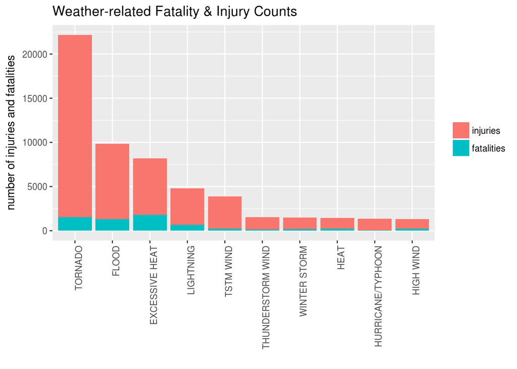

```r
ggplot(melted_top10_injuries_and_fatalities, aes(x = reorder(Event, -Count), y = Count, fill = fatality_injury)) +
         geom_bar(stat = "identity") +
         labs(fill="") +
         labs(x="", y="number of injuries and fatalities") +
         ggtitle("Weather-related Fatality & Injury Counts")+
        theme(axis.text.x = element_text(angle = 90,hjust = 1))
```

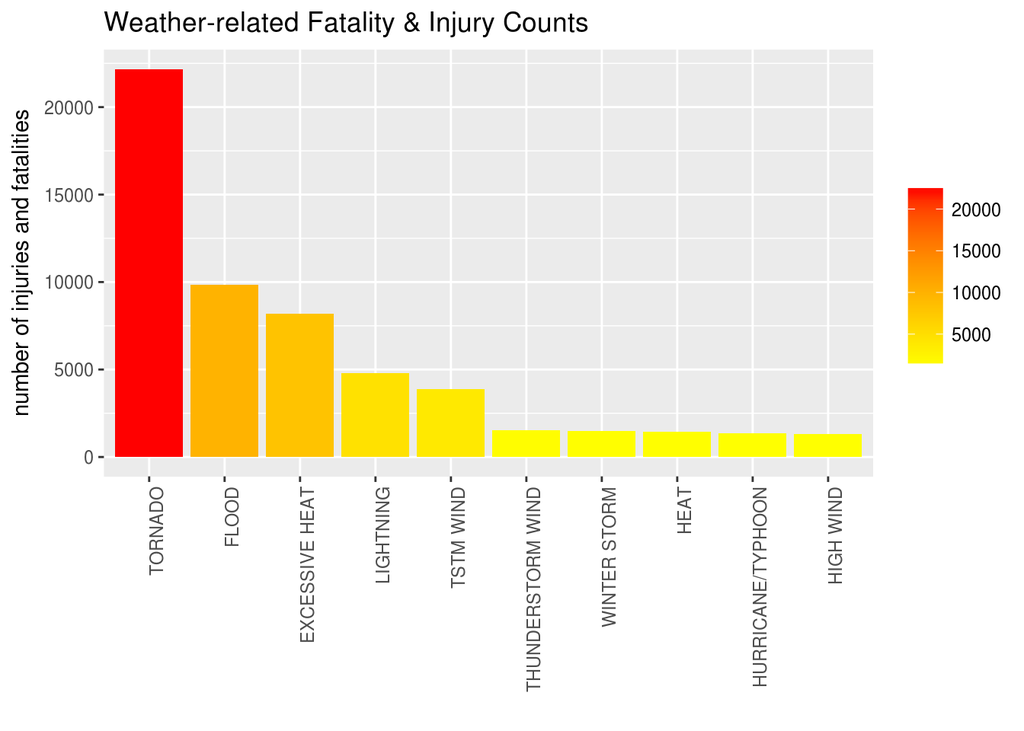

```r
ggplot(top10_injuries_and_fatalities, aes(x = reorder(event,-fatality_injury), y = fatality_injury, fill = fatality_injury)) +
        geom_bar(stat = "identity") +
        labs(fill="") +
        labs(x="", y="number of injuries and fatalities") +
        ggtitle("Weather-related Fatality & Injury Counts")+
        scale_fill_gradient(low="yellow",high = "red") +
        theme(axis.text.x = element_text(angle = 90,hjust = 1))
```

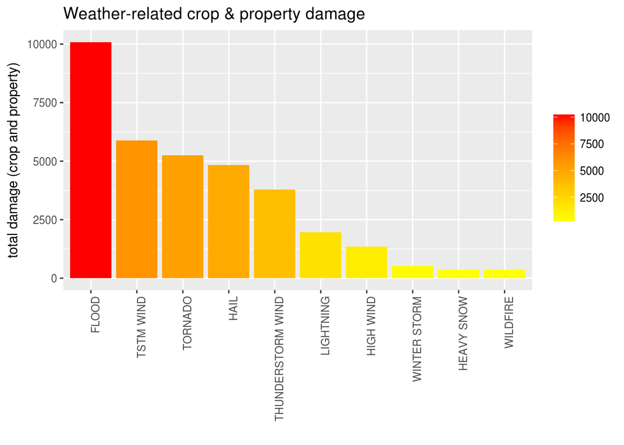

```r
ggplot(top10_damage, aes(x = reorder(event, -total_damage), y = total_damage/1000, fill = total_damage/1000)) +
        geom_bar(stat = "identity") +
        labs(fill="") +
        labs(x="", y="total damage (crop and property)") +
        ggtitle("Weather-related crop & property damage")+
        scale_fill_gradient(low="yellow",high = "red") +
        theme(axis.text.x = element_text(angle = 90,hjust = 1))
```

The analysis shows that across the United States, Tornadoes are most harmful with respect to population health and that floods have the greatest economic consequences.